# Import Data

Begin by importing your dataset from the Import Data submenu in the sidebar, The sidebar gives you the option of uploading your own protein abundance and annotation data, or using a sample dataset from within the MSstatsSampleSize Package. Click Select Data type and select Example from MStatsSampleSize to start exploring

### Protein Abundance File

This must be a csv file in the **wide format**. Rows are proteins, columns are Biological replicates or samples, cells are protein abundances. The following image is an example, example data file can be found **here**

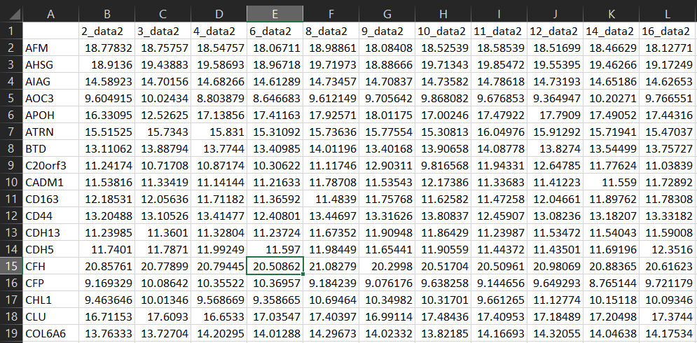

## Annotation File

This must be a csv file in the **long format**. It includes columns BioReplicate for sample ID and Condition for group information. BioReplicate information should be the same as the column names of Preliminary data. The following image is an example, example data file can be found [**here**](https://github.com/Vitek-Lab/MSstatsSampleSize-Shiny/blob/master/OV_SRM_train_annotation.csv)

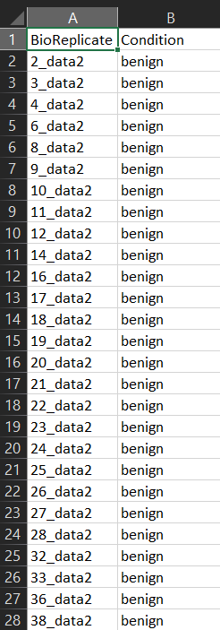

An example dataset from MSstatsSampleSize is also available from within the app. Click Select Data type and select Example from MStatsSampleSize to start exploring `MSstatsSampleSize-GUI`.